# Análise da Temperatura por Tema

Análise da Temperatura por Tema Equipe Leg.go 11/07/2019

Neste relatório, faremos uma análise histórica da Temperatura das proposições agregadas por tema ao longo dos anos.

## Qual foi o comportamento da temperatura geral das proposições acompanhadas pelo Leggo em 2019?

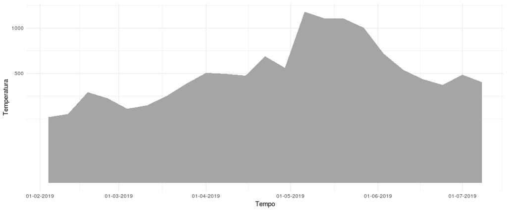

Vamos analisar a temperatura por tema para podermos compreender melhor que temas/proposições influenciaram essas subidas de temperatura observadas.

## Qual foi o comportamento da temperatura de cada tema acompanhado pelo Leggo em 2019?

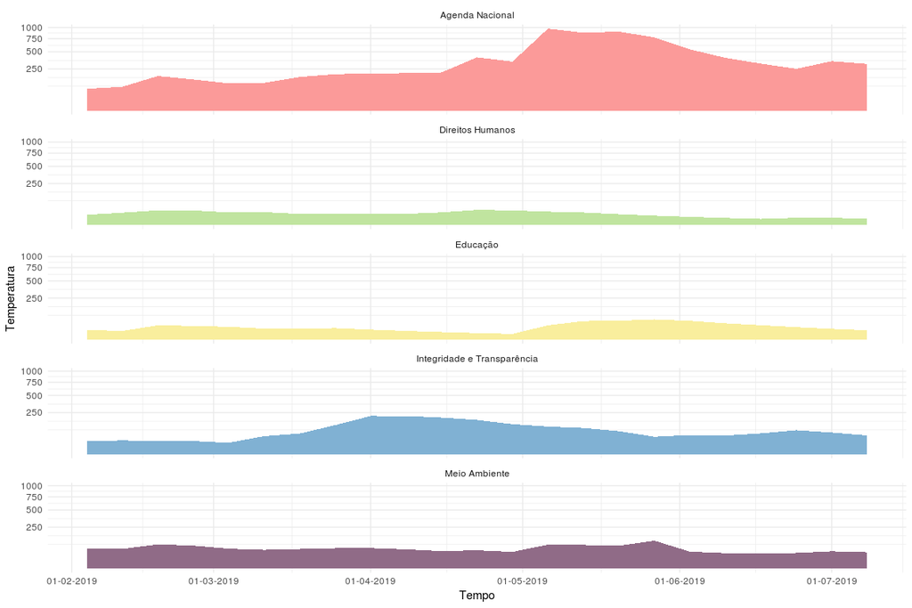

Observando o comportamento da temperatura para cada tema acima, podemos perceber que, no âmbito das proposições acompanhadas pelo Leggo, o tema `Agenda Nacional` tem tido mais atenção por parte do Congresso nos últimos meses, mostrando a força do executivo. Já os outros temas têm tido pouca movimentação, com alguns poucos momentos de crescimento da temperatura.

Podemos verificar alguns picos no histórico da temperatura em cada um dos temas apresentados anteriormente. Vamos analisar os principais picos para cada tema e identificar quais foram as proposições que elevaram a temperatura naquele período.

### Agenda Nacional

No gráfico de temperatura por tema acima, podemos identificar, no tema `Agenda Nacional`, dois picos principais na semana do dia 22/04/2019 e outro na semana do dia 06/05/2019, respectivamente. Abaixo mostramos mais de perto esses picos, numa linha do tempo mais resumida.

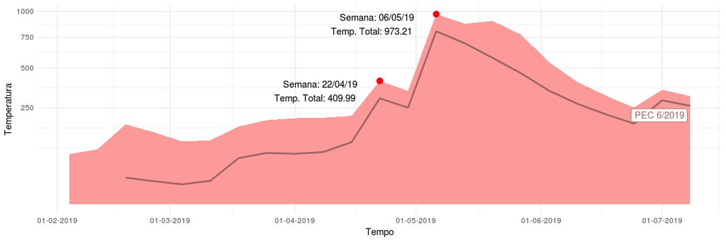

Ao analisarmos os projetos de lei que mais contribuíram para o aumento da temperatura nesses picos observados, percebemos que a principal foi a PEC da Nova Previdência - **PEC 6/2019**.

#### Temperatura das proposições do Tema Agenda Nacional nas Semanas de Destaque

|  | semana | nome_pl | apelido | temperatura_periodo | temperatura_recente | evolucao_temp_recente |
| --- | --- | --- | --- | --- | --- | --- |
| 1 | 2019-04-22T00:00:00Z | PEC 6/2019 | Nova Previdência | 224.29 | 302.41 | 198.26 |
| 2 | 2019-04-22T00:00:00Z | MPV 868/2018\|MPV 868/2018 | Altera o marco legal do saneamento básico | 6.68 | 15.99 | 3.58 |
| 3 | 2019-04-22T00:00:00Z | PLP 38/2019 | Pacote Moro Anticorrupção | 5.04 | 9.87 | 3.43 |
| 4 | 2019-04-22T00:00:00Z | MPV 870/2019\|MPV 870/2019 | Monitoramento e Acompanhamento de ONGs | 6.35 | 15.59 | 3.27 |
| 5 | 2019-04-22T00:00:00Z | PLP 295/2016\|PLS 229/2009 | Lei da Qualidade Fiscal | 2.75 | 2.75 | 2.75 |
| 6 | 2019-04-22T00:00:00Z | MPV 867/2018\|MPV 867/2018 | Programa de Regularização Ambiental | 3.68 | 11.36 | 1.11 |
| 7 | 2019-04-22T00:00:00Z | PL 1864/2019 | Pacote Moro - Crime Organizado | 3.43 | 13.63 | 0.0300000000000011 |

|  | semana | nome_pl | apelido | temperatura_periodo | temperatura_recente | evolucao_temp_recente |
| --- | --- | --- | --- | --- | --- | --- |
| 1 | 2019-05-06T00:00:00Z | PEC 6/2019 | Nova Previdência | 616.5 | 805.17 | 553.62 |
| 2 | 2019-05-06T00:00:00Z | MPV 870/2019\|MPV 870/2019 | Monitoramento e Acompanhamento de ONGs | 31.97 | 41.49 | 28.8 |
| 3 | 2019-05-06T00:00:00Z | MPV 867/2018\|MPV 867/2018 | Programa de Regularização Ambiental | 26.36 | 35 | 23.48 |
| 4 | 2019-05-06T00:00:00Z | MPV 868/2018\|MPV 868/2018 | Altera o marco legal do saneamento básico | 24.36 | 34.1 | 21.11 |
| 5 | 2019-05-06T00:00:00Z | PEC 45/2019 | Reforma tributária | 7.68 | 13.41 | 5.77 |
| 6 | 2019-05-06T00:00:00Z | PL 1864/2019 | Pacote Moro - Crime Organizado | 3.36 | 11.03 | 0.809999999999999 |

### Direitos Humanos

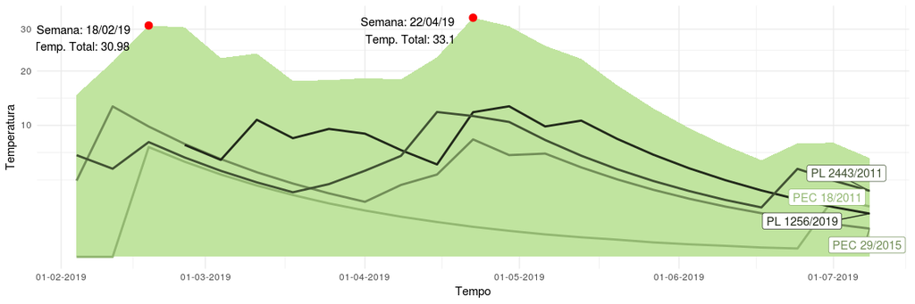

Ao analisarmos os projetos de lei que mais contribuíram para o aumento da temperatura nesses picos observados, percebemos que as principais foram a PEC que Autoriza o Trabalho Infantil a partir dos Quatorze Anos - **PEC 18/2011**, a PL da Situação Jurídica do Estrangeiro no Brasil - **PL 2443/2011**, a PL da Extição das Cotas de Candidaturas Femininas - **PL 1256/2019** e a PEC Antiaborto - **PEC 29/2015**

#### Temperatura das proposições do Tema Direitos Humanos nas Semanas de Destaque

|  | semana | nome_pl | apelido | temperatura_periodo | temperatura_recente | evolucao_temp_recente |
| --- | --- | --- | --- | --- | --- | --- |
| 1 | 2019-02-18T00:00:00Z | PEC 18/2011 | Autoriza trabalho a partir dos quatorze anos | 6.97 | 6.97 | 6.97 |
| 2 | 2019-02-18T00:00:00Z | PL 2443/2011 | Situação Jurídica do Estrangeiro no Brasil | 4.25 | 7.62 | 3.13 |
| 3 | 2019-02-18T00:00:00Z | PL 3974/2012 | Trabalho infantil artístico | 2 | 2 | 1.99 |
| 4 | 2019-02-18T00:00:00Z | PLS 231/2015 | Trabalho infantil artístico e despostivo | 1.25 | 3.61 | 0.47 |

|  | semana | nome_pl | apelido | temperatura_periodo | temperatura_recente | evolucao_temp_recente |
| --- | --- | --- | --- | --- | --- | --- |
| 1 | 2019-04-22T00:00:00Z | PL 1256/2019 | Extinção das Cotas de Candidaturas Femininas | 8.4 | 12.11 | 7.17 |
| 2 | 2019-04-22T00:00:00Z | PEC 29/2015 | PEC Antiaborto | 5.04 | 7.98 | 4.06 |

## Educação

Observando a temperatura histórica do tema `Educação`, é possível perceber três picos um na semana do dia 18/02/2019, na semana do dia 06/05/2019 e outro na semana do dia 27/05/2019. Abaixo mostramos mais de perto esses picos, numa linha do tempo mais resumida.

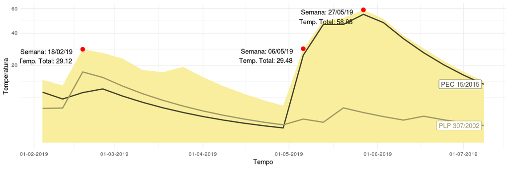

Ao analisarmos os projetos de lei que mais contribuíram para o aumento da temperatura nesses picos observados, percebemos que as principais foram a PEC de Tornar o FUNDEB Permanente - **PEC 15/2015** e a **PLP 307/2002** que também trata sobre o FUNDEB.

#### Temperatura das proposições do Tema Educação nas Semanas de Destaque

|  | semana | nome_pl | apelido | temperatura_periodo | temperatura_recente | evolucao_temp_recente |
| --- | --- | --- | --- | --- | --- | --- |
| 1 | 2019-02-18T00:00:00Z | PLP 307/2002 | Deixa de incluir FUNDEF no limite de gastos com pessoal | 13.69 | 16.71 | 12.69 |
| 2 | 2019-02-18T00:00:00Z | PL 3020/2011 | Piso salarial do magistério público da educação básica - Marchezan | 3.61 | 3.61 | 3.61 |
| 3 | 2019-02-18T00:00:00Z | PEC 15/2015 | Tornar o FUNDEB permanente (Câmara) | 3.61 | 8.39 | 2.01 |

|  | semana | nome_pl | apelido | temperatura_periodo | temperatura_recente | evolucao_temp_recente |
| --- | --- | --- | --- | --- | --- | --- |
| 1 | 2019-05-06T00:00:00Z | PEC 15/2015 | Tornar o FUNDEB permanente (Câmara) | 25.01 | 25.55 | 24.82 |
| 2 | 2019-05-06T00:00:00Z | PLP 307/2002 | Deixa de incluir FUNDEF no limite de gastos com pessoal | 1.07 | 1.87 | 0.8 |

|  | semana | nome_pl | apelido | temperatura_periodo | temperatura_recente | evolucao_temp_recente |
| --- | --- | --- | --- | --- | --- | --- |
| 1 | 2019-05-27T00:00:00Z | PEC 15/2015 | Tornar o FUNDEB permanente (Câmara) | 19.98 | 54.97 | 8.31 |

## Integridade e Transparência

Para o tema `Integridade e Transparência`, observamos um aumento mais expressivo na semana do dia 01/04/2019 e outro na semana do dia 24/06/2019. Abaixo mostramos mais de perto esse comportamento, numa linha do tempo mais resumida.

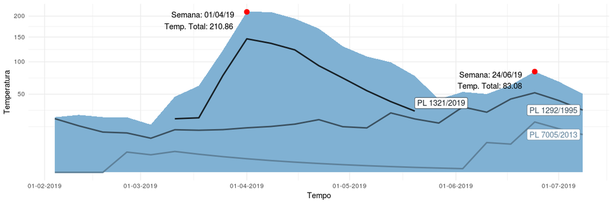

Ao analisarmos os projetos de lei que mais contribuíram para o aumento da temperatura nesses picos observados, percebemos que as principais foram a da Anistia Tributária para Partidos - **PL 1321/2019**, o PL das Compras Públicas (Nova Lei de Licitações) - **PL 1292/1995 | PLS 163/1995** e o PL de Assinatura eletrônica em Leis de Iniciativa Popular - **PL 7005/2013 | PLS 129/2010**.

#### Temperatura das proposições do Tema Integridade e Transparência nas Semanas de Destaque

|  | semana | nome_pl | apelido | temperatura_periodo | temperatura_recente | evolucao_temp_recente |
| --- | --- | --- | --- | --- | --- | --- |
| 1 | 2019-04-01T00:00:00Z | PL 1321/2019\|PL 1321/2019 | Anistia Tributária para Partidos | 88.58 | 146.03 | 69.43 |
| 2 | 2019-04-01T00:00:00Z | MPV 869/2018 | Proteção de Dados Pessoais | 9 | 11.51 | 8.16 |
| 3 | 2019-04-01T00:00:00Z | PL 1202/2007 | Disciplina a atividade de lobby | 10.08 | 19.41 | 6.97 |
| 4 | 2019-04-01T00:00:00Z | PLS 429/2017 | Programa de Integridade para Partidos | 6.79 | 16.17 | 3.67 |
| 5 | 2019-04-01T00:00:00Z | PL 1292/1995\|PLS 163/1995 | PL das Compras Públicas (Nova Lei de Licitações) | 5.04 | 16.23 | 1.31 |

|  | semana | nome_pl | apelido | temperatura_periodo | temperatura_recente | evolucao_temp_recente |
| --- | --- | --- | --- | --- | --- | --- |
| 1 | 2019-06-24T00:00:00Z | PL 7005/2013\|PLS 129/2010 | Assinatura eletrônica em Leis de Iniciativa Popular | 15.87 | 20.76 | 14.24 |
| 2 | 2019-06-24T00:00:00Z | PL 1292/1995\|PLS 163/1995 | PL das Compras Públicas (Nova Lei de Licitações) | 18.84 | 51.88 | 7.83000000000001 |
| 3 | 2019-06-24T00:00:00Z | PLS 429/2017 | Programa de Integridade para Partidos | 1.68 | 3.09 | 1.21 |

## Meio Ambiente

Finalmente, observando a evolução histórica da temperatura do tema `Meio Ambiente`, percebemos três pico um na semana do dia 18/02/2019, outro na semana do dia 06/05/2019 e um na semana do dia 27/05/2019. Abaixo mostramos mais de perto esse comportamento, numa linha do tempo mais resumida.

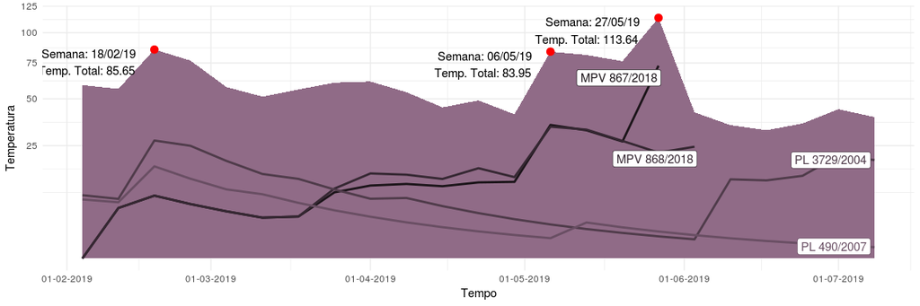

Ao analisarmos os projetos de lei que mais contribuíram para o aumento da temperatura nesses picos observados, percebemos que as principais foram a Lei do Licenciamento Ambiental - **PL 3729/2004**, o Estatuto do Índio - **PL 490/2007**, além de duas Medidas Provisórias: a do Programa de Regularização Ambiental - **MPV 867/2018** e a que Altera o marco legal do Saneamento Básico - **MPV 868/2018**.

#### Temperatura das proposições do Tema Meio Ambiente nas Semanas de Destaque

|  | semana | nome_pl | apelido | temperatura_periodo | temperatura_recente | evolucao_temp_recente |
| --- | --- | --- | --- | --- | --- | --- |
| 1 | 2019-02-18T00:00:00Z | PL 3729/2004 | Lei do Licenciamento Ambiental | 22.09 | 27.31 | 20.34 |
| 2 | 2019-02-18T00:00:00Z | PL 490/2007 | Estatuto do Índio | 12.01 | 16.66 | 10.46 |
| 3 | 2019-02-18T00:00:00Z | PLS 232/2016 | Reforma do setor elétrico (Senado) | 1.25 | 4.14 | 0.29 |

|  | semana | nome_pl | apelido | temperatura_periodo | temperatura_recente | evolucao_temp_recente |
| --- | --- | --- | --- | --- | --- | --- |
| 1 | 2019-05-06T00:00:00Z | MPV 867/2018\|MPV 867/2018 | Programa de Regularização Ambiental | 26.36 | 35 | 0 |
| 2 | 2019-05-06T00:00:00Z | MPV 868/2018\|MPV 868/2018 | Altera o marco legal do saneamento básico | 24.36 | 34.1 | 0 |
| 3 | 2019-05-06T00:00:00Z | PL 1551/2019 | Fim da Reserva Legal | 0 | 4.49 | -1.5 |
| 4 | 2019-05-06T00:00:00Z | PL 9950/2018 | Lei do Pantanal - Molon | 2.68 | 3.71 | 2.33 |
| 5 | 2019-05-06T00:00:00Z | PL 3729/2004 | Lei do Licenciamento Ambiental | 0 | 2.27 | -0.76 |
| 6 | 2019-05-06T00:00:00Z | PL 6969/2013 | PNCMar | 0 | 1.36 | -0.46 |
| 7 | 2019-05-06T00:00:00Z | PL 490/2007 | Estatuto do Índio | 0 | 0.81 | -0.27 |
| 8 | 2019-05-06T00:00:00Z | PLS 495/2017 | Mercado da água | 0 | 0.62 | -0.21 |
| 9 | 2019-05-06T00:00:00Z | PL 6670/2016 | Política Governo de Redução de Agrotóxico | 0 | 0.53 | -0.18 |
| 10 | 2019-05-06T00:00:00Z | PLS 168/2018 | Lei Geral de Licenciamento Ambiental | 0 | 0.4 | -0.13 |

[output cut: 6 more lines]

|  | semana | nome_pl | apelido | temperatura_periodo | temperatura_recente | evolucao_temp_recente |
| --- | --- | --- | --- | --- | --- | --- |
| 1 | 2019-05-27T00:00:00Z | PLS 495/2017 | Mercado da água | 1.93 | 2.19 | 1.84 |